# TP1 Regresión Lineal Simple

Habría que ver la independencia de las variables para ver si el resultado se mantiene, aplicamos el test de Durbin-Watson:

```r
library(car)
dwt(model)
```

```
##  lag Autocorrelation D-W Statistic p-value
##    1       0.1019283      1.783079    0.61
##  Alternative hypothesis: rho != 0
```

Graficamos:

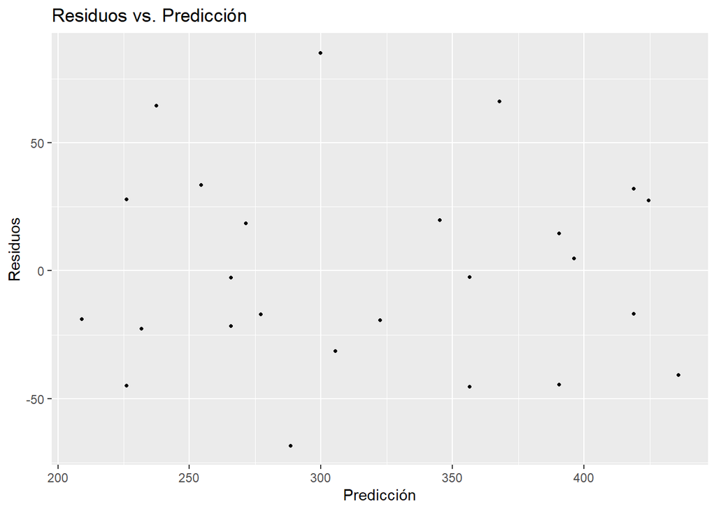

```r
ggplot(colest2, aes(x = prediccion, y = residuos)) +
  geom_point(shape = 20) +
  labs(x = "Predicción", y = "Residuos",
       title = "Residuos vs. Predicción")
```

No parece haber un patrón entre los residuos, por lo cual no se puede ver heterocedasticidad. En clase el código para ver esto era este:

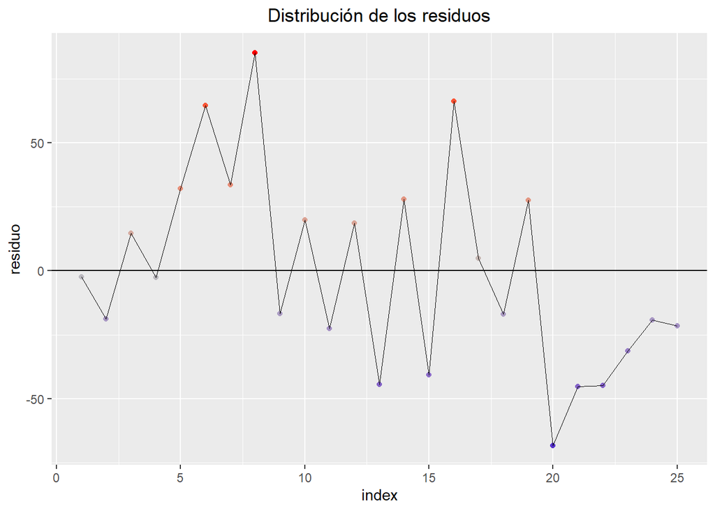

```r
ggplot(data = colest2, aes(x = seq_along(residuos), y = residuos)) +
  geom_point(aes(color = residuos)) +
  scale_color_gradient2(low = "blue3", mid = "grey", high = "red") +
  geom_line(size = 0.3) + labs(title = "Distribución de los residuos", x = "index", y = "residuo")+
  geom_hline(yintercept = 0) +
  theme(plot.title = element_text(hjust = 0.5), legend.position = "none")
```

No me queda claro como interpretarlo en este caso

## Ejercicio1.4. Una empresa desarrolló un sistema de energía solar para calentar el agua para una caldera que es parte del sistema de energía del proceso productivo.Existe el interés de controlar la estabilidad del sistema, para ello se monitorea el mismo y se registran los datos cada hora. Los datos se encuentran disponibles en el archivo energia.xlsx

```r
energia <- read_excel('energia.xlsx')
```

### (a) Realizar el diagrama de dispersión y evaluar si un modelo de regresión lineal es adecuado.

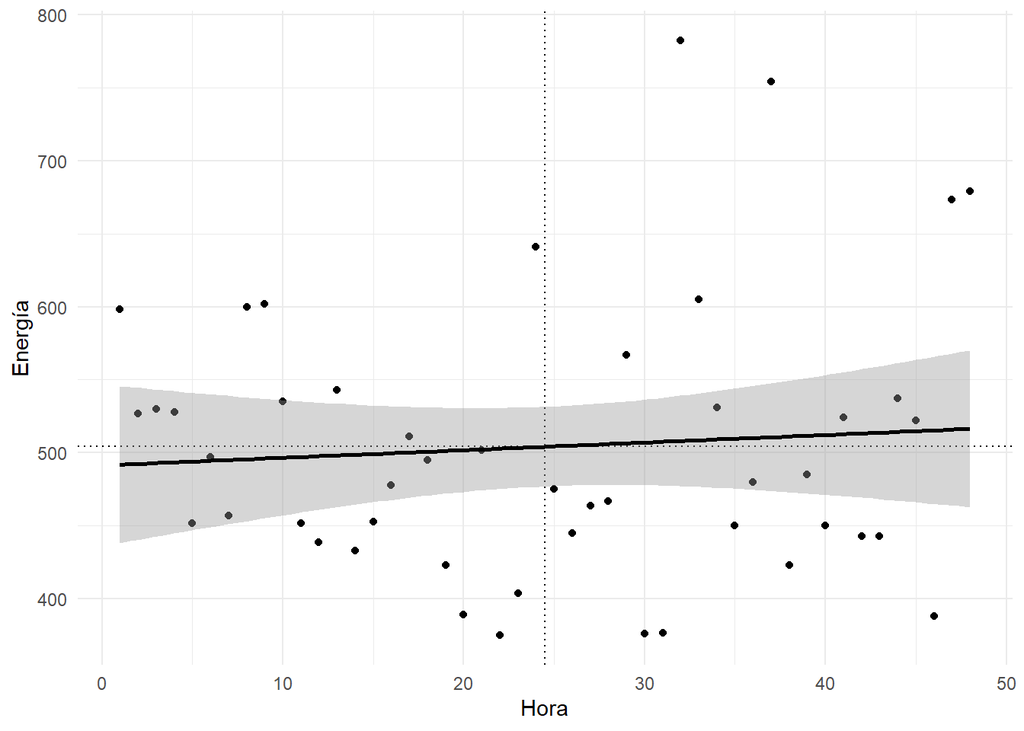

```r
promediosE <- colMeans(energia)
ggplot(energia, aes(Hora, Energía)) +
  geom_point() +
  geom_vline(xintercept=promediosE[1],linetype="dotted") +
  geom_hline(yintercept=promediosE[2],linetype="dotted") +
  geom_smooth(method = "lm", se = TRUE, color = "black") +
  theme_minimal()
```

No parecería ser adecuado un modelo lineal

### (b) Estimar un modelo lineal y verificar la normalidad de los residuos del mismo.

```r
modelE <- lm(Energía ~ Hora, data = energia)

shapiro.test(modelE$residuals)
```

```
##
##  Shapiro-Wilk normality test
##
## data:  modelE$residuals
## W = 0.92988, p-value = 0.006752
```

```r
summary(modelE)
```

```
##
## Call:
## lm(formula = Energía ~ Hora, data = energia)
##
## Residuals:
##     Min      1Q  Median      3Q     Max
## -131.12  -60.60  -24.31   37.29  273.84
##
## Coefficients:
##             Estimate Std. Error t value Pr(>|t|)
## (Intercept) 491.4894    27.5044  17.869   <2e-16 ***
## Hora          0.5208     0.9772   0.533    0.597
## ---
## Signif. codes:  0 '***' 0.001 '**' 0.01 '*' 0.05 '.' 0.1 ' ' 1
##
## Residual standard error: 93.79 on 46 degrees of freedom
## Multiple R-squared:  0.006138,   Adjusted R-squared:  -0.01547
## F-statistic: 0.2841 on 1 and 46 DF,  p-value: 0.5966
```

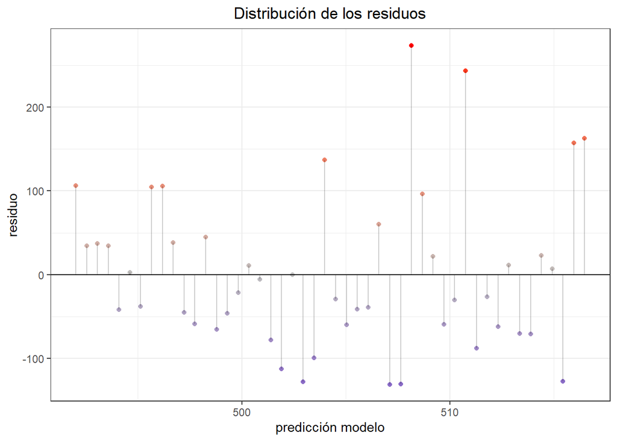

```r
energia2<-energia
energia2$prediccion <- modelE$fitted.values
energia2$residuos <- modelE$residuals


ggplot(data = energia2, aes(x = prediccion, y = residuos)) +
  geom_point(aes(color = residuos)) +
  scale_color_gradient2(low = "blue3", mid = "grey", high = "red") +
  geom_hline(yintercept = 0) + geom_segment(aes(xend = prediccion, yend = 0), alpha = 0.2) +
  labs(title = "Distribución de los residuos", x = "predicción modelo", y = "residuo") +
  theme_bw() +
  theme(plot.title = element_text(hjust = 0.5), legend.position = "none")
```

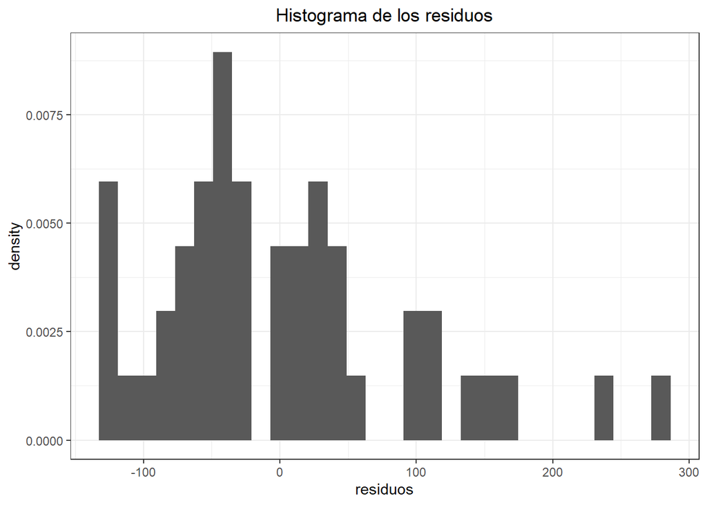

```r
ggplot(data = energia2, aes(x = residuos)) + geom_histogram(aes(y = ..density..)) +
  labs(title = "Histograma de los residuos") + theme_bw() +
  theme(plot.title = element_text(hjust = 0.5))
```

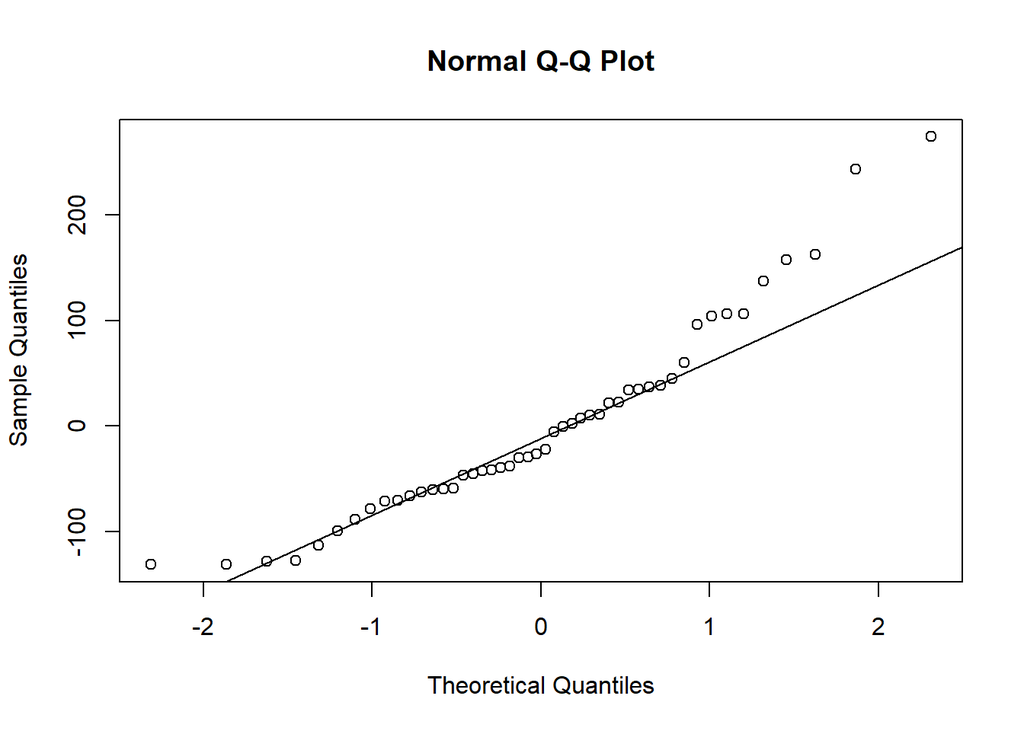

```r
qqnorm(modelE$residuals)
qqline(modelE$residuals)
```

Graficamos:

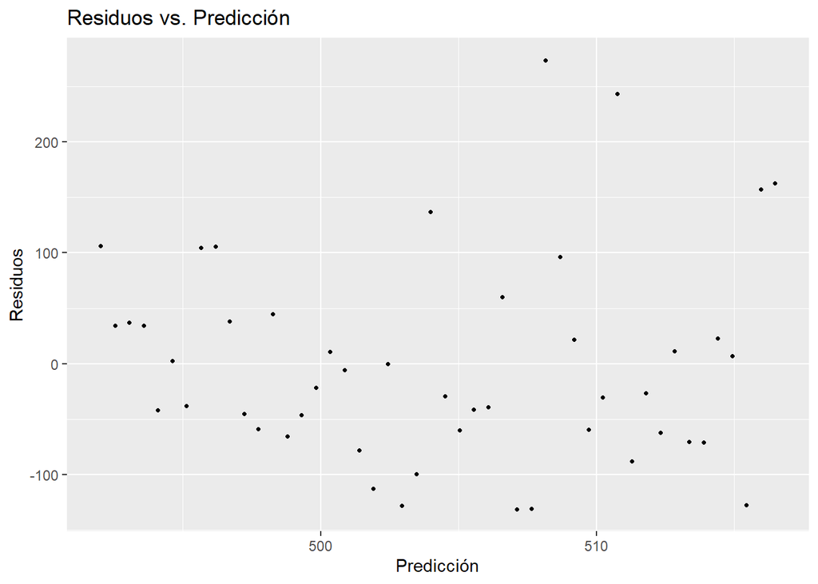

```r
ggplot(energia2, aes(x = prediccion, y = residuos)) +
  geom_point(shape = 20) +
  labs(x = "Predicción", y = "Residuos",
       title = "Residuos vs. Predicción")
```

Aparentemente en este caso no hay normalidad porque hay agrupamiento de los residuos habiendo algunos puntos que se alejan mucho del resto

### (c) En caso de rechazar este supuesto buscar una transformación lineal para este modelo y aplicarla.

```r
library(MASS)
box_cox_result <-boxcox(Energía ~ Hora, lambda = -5:2, data = energia)
```

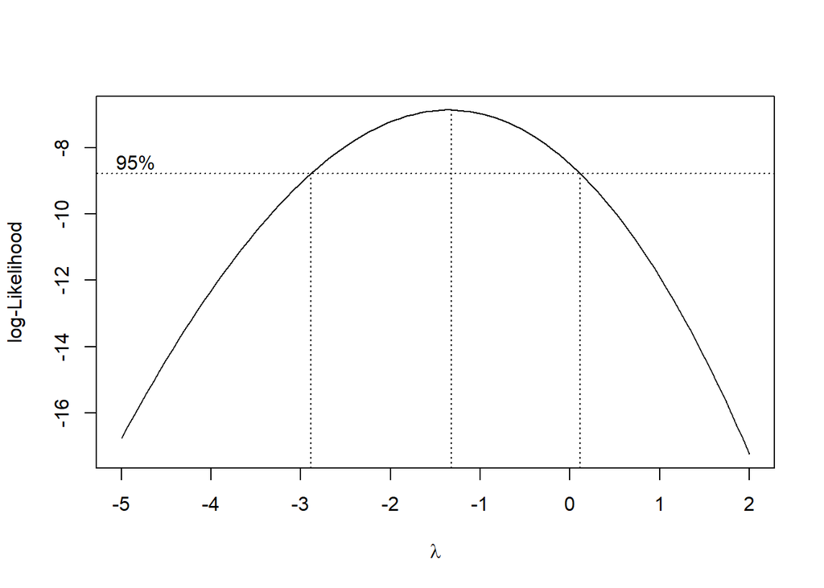

```r
best_box_cox <- box_cox_result$x[which.max(box_cox_result$y)]
modelE2 <- lm((Energía)^(best_box_cox) ~ Hora, data = energia)
summary(modelE2)
```

```
##
## Call:
## lm(formula = (Energía)^(best_box_cox) ~ Hora, data = energia)
##
## Residuals:
##        Min         1Q     Median         3Q        Max
## -1.290e-04 -3.263e-05  3.849e-06  3.599e-05  1.150e-04
##
## Coefficients:
##               Estimate Std. Error t value Pr(>|t|)
## (Intercept)  2.779e-04  1.787e-05   15.55   <2e-16 ***
## Hora        -1.251e-08  6.350e-07   -0.02    0.984
## ---
## Signif. codes:  0 '***' 0.001 '**' 0.01 '*' 0.05 '.' 0.1 ' ' 1
##
## Residual standard error: 6.094e-05 on 46 degrees of freedom
## Multiple R-squared:  8.444e-06,  Adjusted R-squared:  -0.02173
## F-statistic: 0.0003884 on 1 and 46 DF,  p-value: 0.9844
```

```r
shapiro.test(modelE2$residuals)
```

```
##
##  Shapiro-Wilk normality test
##
## data:  modelE2$residuals
## W = 0.98002, p-value = 0.5796
```

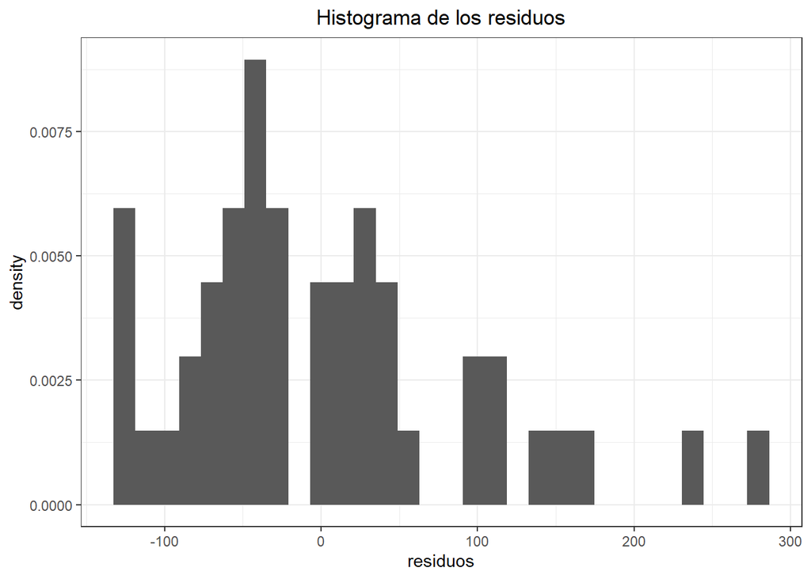

```r
energia3<-energia
energia3$Energía <- log(energia$Energía)
energia3$prediccion <- modelE2$fitted.values
energia3$residuos <- modelE2$residuals


ggplot(data = energia2, aes(x = residuos)) + geom_histogram(aes(y = ..density..)) +
  labs(title = "Histograma de los residuos") + theme_bw() +
  theme(plot.title = element_text(hjust = 0.5))
```

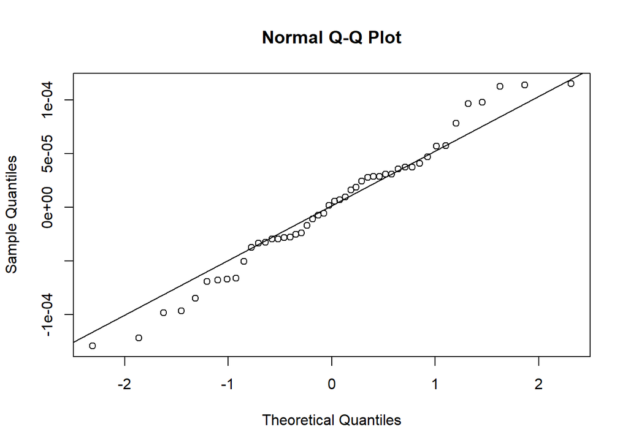

```r
qqnorm(modelE2$residuals)
qqline(modelE2$residuals)
```

### (d) Realizar el análisis diagnóstico del nuevo modelo y estimar un intervalo de confianza y un intervalo de predicción para 27.5 hs con ambos modelos. Comparar los intervalos.